# Propaganda Wars

Amanda Franklin-Ryan

2023-04-25

## Introduction

### Atrocity Propaganda

*“History stopped in 1936- after that, there was only propaganda”* - **George Orwell**

Atrocity propaganda is nothing new, with lurid tales of fabricated massacres stretching back to the Crusades, but now storytelling is easier than ever before; all you need is a mobile and internet connection. There are now more hours of Syrian conflict footage online, than time elapsed since the war started.Almost five million people are currently trapped in Khartoum as Sudanese generals Abdel Fattah al-Burhan and Mohamed Hamdan Daglo vie for power and Twitter is awash with fake footage taken from conflicts in Yemen, Libya and even a computer game.(“Tanks And Twitter: Sudan Generals’ Multi-Pronged War,” n.d.) With most Twitter accounts geolocation data switched off, it’s game on for opportunists worldwide to create and share their own realities. Even with image metadata and reverse image search, it’s almost impossible to ascertain whether shared images are accurate, misrepresentative, staged or concocted by government backed bots. [DALL.E2](https://openai.com/product/dall-e-2) will only make things worse, with the potential power to conjure up bespoke atrocities in every style from gritty World War II grayscale to heartrending full colour closeup at the click of a mouse.

Yet in a world where fiction seems higher definition than reality, satellite imagery could offer a glimmer of hope. In March 2022 Ukrainians reported the rape, murder and torture of hundreds of civilians in Bucha, with bodies strewn across the streets. Unsurprisingly, the Russian Defence Ministry immediately dismissed the allegations as, “*another production of the Kyiv regime for the Western media*”, blaming Ukrainian soldiers themselves for the killings. (Mirovalev, n.d.)However Maxar satellite data corroborated the Ukrainian narrative illustrating the bodies had been present long before Ukrainian forces entered the area.(“Bucha Killings: Satellite Image of Bodies Site Contradicts Russian Claims” 2022)

### Raqqa: The Perfect Perpetratorless Crime

Created in 2019, Amnesty International’s [Strike Tracker](https://decoders.amnesty.org/projects/strike-tracker#decode-results) used satellite imagery coupled with crowd sourced image labelling to create an accurate timeline for the 2017 US led Coalition bombing in the Syrian city of Raqqa. Attempting to destroy Islamic State’s “Caliphate”, Coalition forces fired over 30,000 missiles in a four-month bombardment, destroying 80% of the city and killing and injuring thousands of civilians. Pinning down responsibility was challenging as the Coalition accused ISIS, Russia blamed the US and the US denied all responsibility ruling less than one percent of civilian casualty reports “credible”.(April 25 2019 and P.m, n.d.)

Amnesty International enlisted thousands of digital activists to analyse a series of satellite photos of the same building to identify the exact date it was destroyed. After following a short interactive tutorial volunteers were presented with a new series of images to label. Combining the crowd sourced strike timeline with witness testimony and interviews, Amnesty forced the Coalition to admit responsibility for 159 civilian deaths.(“IS Conflict: Coalition Strikes on Raqqa ’Killed 1,600 Civilians’” 2019)

- Identify and download suitable satellite images from the SentinelHub API, an R wrapper will also be written to simplify this process
- Collect and visualise data from UNOSAT illustrating the position of the coalition strikes (for the purposes of the future machine learning model this represents the ground truth)
- Download series of news articles from Guardian/New York Times API illustrating who different media outlets hold responsible for the civilian deaths.

## Medium Resolution Satellite Data (Sentinel-1 and Sentinel-2)

### Overview

Launched by the European Space Agency in June 2015, primarily for agricultural monitoring and emergency management, Sentinel-2 collects land and ocean imagery to a maximum resolution of 10m every 5 days. (“Sentinel-2 - Missions - Sentinel Online,” n.d.)The imagery consists of 13 spectral bands ranging from visible (red, green, blue) to near infrared (NIR) and short wave infrared (SWIR), it also includes specific frequencies for identifying vegetation (bands 5-8a) and clouds (Band 10: Cirrus).(“Custom Scripts Tutorial,” n.d.)

Sentinel -1 was launched by the European Commission’s Copernicus Project a year earlier in April 2014, and collects Synthetic Aperture Radar (SAR) data every 10 days. (“Sentinel-1 - Missions - Sentinel Online,” n.d.)While Sentinel 2’s optical sensors allow it to capture imagery from reflected sunlight, Sentinel-1 produces its own electromagnetic beam (with 8 bands between 0.3GHz and 40GHz) and records its reflection. The longer wavelength radar frequencies not only pass straight through clouds so can be used in any weather, but penetrate soil and sand [revealing hidden underground artefacts](https://earthobservatory.nasa.gov/features/SpaceArchaeology). Additionally, phase data can be extracted from the radar signal and used to calculate differences in surface topography with an accuracy of up to a few centimetres. (Earth Science Data Systems 2020) Combining these height difference calculations with machine learning techniques, one 2022 study identified buildings damaged by earthquakes.(Earth Science Data Systems 2020)

Real colour images can be constructed by superimposing red, green and blue bands but often it is more revealing to use false colour. The optimal frequency depends on the exact nature of the task. Infrared is generally preferable for forestry mapping as soil and vegetation are difficult to differentiate in true colour imagery (as their spectral reflectances are almost identical in the visible range), however there is a difference of almost 30% in the mid-infrared band. (“Custom Scripts Tutorial,” n.d.)

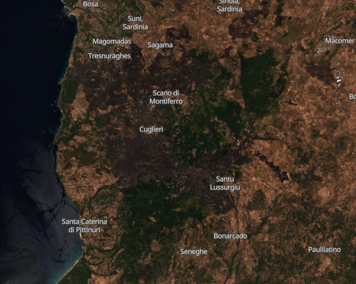

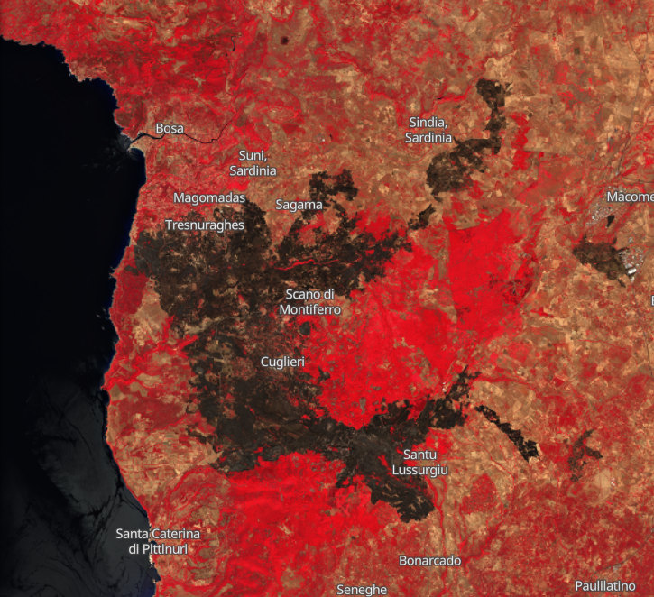

### Data Download Options

Sentinel Satellite data is available free online through the following portals:

- [EO Browser](https://apps.sentinel-hub.com/eo-browser/?zoom=10&lat=41.9&lng=12.5&themeId=DEFAULT-THEME&toTime=2023-04-26T12%3A08%3A08.207Z)
- [Copernicus Open Access Hub AP](https://scihub.copernicus.eu/)I
- [Sentinel Hub API](https://docs.sentinel-hub.com/api/latest/api/process/)

The EO browser is an interface allowing registered users to easily select and download satellite imagery of regions of interest from an interactive map. Using simple drop down menus users can also select the relevant time range, level of maximum cloud coverage and type of image. Results are presented as a simple image list which not only offers the option of fusing single images into standard combinations including real colour, false colour and Normalised Difference Vegetation Index (NDVI), but also of creating custom combinations. Images can be saved, shared, pinned, downloaded and automatically woven into time lapse sequences.

Although it’s possible to easily visualise, download and customise satellite imagery using EO Browser and sen2r, this project downloaded all imagery directly from the Sentinel Hub API. To use satellite data in a potential machine learning project I wanted to create an efficient data pipeline to collect and process large numbers of satellite photos without scrolling through multiple images manually via the browser. The sen2R package does offer this functionality but only for Sentinel-2 data, also it requires sci hub log-in which is only activated one week after registration (and would have made meeting this deadline impossible :))

### Accessing the Sentinel Hub API

```r
library(httr)
library(brio)# for loading text file with no extension
library(rio)
library(png)

### --- Oauth Authorisation to access API

# IDs and secrets
client_id <- readRDS("Secrets/oauth_client_id.rds")
client_secret <- readRDS("Secrets/oauth_secret.rds")

# Create the app
app <- oauth_app(appname = "SatelliteImageryAnalysis",
                 key = client_id,
                 secret = client_secret)

# Create the oauth endpoint
endpoint <- oauth_endpoint(
  request = NULL,
  authorize = NULL,
  access = "token",
  base_url = "https://services.sentinel-hub.com/oauth")

# Cache the token to prevent API being called multiple times (token lasts 1 hour)
options(httr_oauth_cache=T) # prevents pop-up asking to cache token
token <- oauth2.0_token(endpoint = endpoint,
                        app = app,
                        use_basic_auth = T,
                        client_credentials = T)
```

```python
  request={
    "input": {
        "bounds": {
            "properties": {
                "crs": "http://www.opengis.net/def/crs/OGC/1.3/CRS84"
            },
            "bbox": [
                13.822174072265625,
                45.85080395917834,
                14.55963134765625,
                46.29191774991382
            ]
        },
        "data": [
            {
                "type": "sentinel-2-l2a",
                "dataFilter": {
                    "timeRange": {
                        "from": "2018-10-01T00:00:00Z",
                        "to": "2018-12-31T00:00:00Z"
                    }
                }
            }
        ]
    },
    "output": {
        "width": 512,
        "height": 512
    }
}
```

Ideally the POST request should be sent as a multipart form, which would allow the evalscript to be written in ordinary JSON. HoweverI was unable to do this correctly, so as a workaround escaped the entire JSON Evalscript section (using [this tool)](https://www.freeformatter.com/json-escape.html) and sent it as part of the same request. The image information was then extracted from the response object and the file saved as png.

```r
### --- Build request

request <- read_file("R Scripts/POST body request") # loads request from JSON in text file
sentinel_endpoint <- "https://services.sentinel-hub.com/api/v1/process"

# Specify which formats are accepted in request(JSON) and response(png)
response <- httr::POST(sentinel_endpoint,
                       body=request,
                       add_headers(Accept = "image/png",
                                   `Content-Type`="application/json",
                                   Authorization = paste("Bearer", token$credentials[[1]], sep = " ")))
```